# DEA 1 - Budweiser

Shijo Joseph & Douglas Yip

10/6/2021

# Budweiser

## Executive Summary

```r
#uploads the data into R to start analysis from Github

Breweries <- read.csv("https://raw.githubusercontent.com/sajoseph-smu/Case-Study-1---Budwieser/main/Breweries.csv", header = T)

summary(Breweries)
```

```
##     Brew_ID          Name               City              State
##  Min.   :  1.0   Length:558         Length:558         Length:558
##  1st Qu.:140.2   Class :character   Class :character   Class :character
##  Median :279.5   Mode  :character   Mode  :character   Mode  :character
##  Mean   :279.5
##  3rd Qu.:418.8
##  Max.   :558.0
```

```r
Beers <- read.csv("https://raw.githubusercontent.com/sajoseph-smu/Case-Study-1---Budwieser/main/Beers.csv", header = T)
summary(Beers)
```

```
##      Name              Beer_ID            ABV               IBU
##  Length:2410        Min.   :   1.0   Min.   :0.00100   Min.   :  4.00
##  Class :character   1st Qu.: 808.2   1st Qu.:0.05000   1st Qu.: 21.00
##  Mode  :character   Median :1453.5   Median :0.05600   Median : 35.00
##                     Mean   :1431.1   Mean   :0.05977   Mean   : 42.71
##                     3rd Qu.:2075.8   3rd Qu.:0.06700   3rd Qu.: 64.00
##                     Max.   :2692.0   Max.   :0.12800   Max.   :138.00
##                                      NA's   :62        NA's   :1005
##    Brewery_id       Style               Ounces
##  Min.   :  1.0   Length:2410        Min.   : 8.40
##  1st Qu.: 94.0   Class :character   1st Qu.:12.00
##  Median :206.0   Mode  :character   Median :12.00
##  Mean   :232.7                      Mean   :13.59
##  3rd Qu.:367.0                      3rd Qu.:16.00
##  Max.   :558.0                      Max.   :32.00
##
```

### 1. How many breweries are present in each state?

```r
#This code will identify the number of breweries for each state
#How many Breweries are in each state?

SummaryBrewery <- Breweries %>% count(State, sort = TRUE)
names(SummaryBrewery)[2] <- "Brewery_Count"
#Summary of Breweries
SummaryBrewery
```

```
##    State Brewery_Count
## 1     CO            47
## 2     CA            39
## 3     MI            32
## 4     OR            29
## 5     TX            28
## 6     PA            25
## 7     MA            23
## 8     WA            23
## 9     IN            22
## 10    WI            20
## 11    NC            19
## 12    IL            18
## 13    NY            16
## 14    VA            16
```

[output cut: 37 more lines]

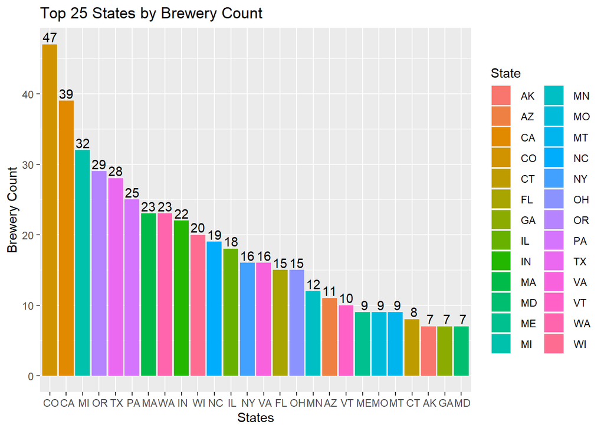

```r
# Top 25 States with Most Breweries


top_n(SummaryBrewery,25,Brewery_Count) %>% ggplot(mapping = aes(x = reorder(State,-Brewery_Count), y = Brewery_Count, fill = State)) + geom_bar(stat = 'identity') + ggtitle("Top 25 States by Brewery Count") + xlab("States") + ylab("Brewery Count") +geom_text(aes(label = format(Brewery_Count,big.mark =',')), position = position_dodge(width = .9), vjust = -.25)
```

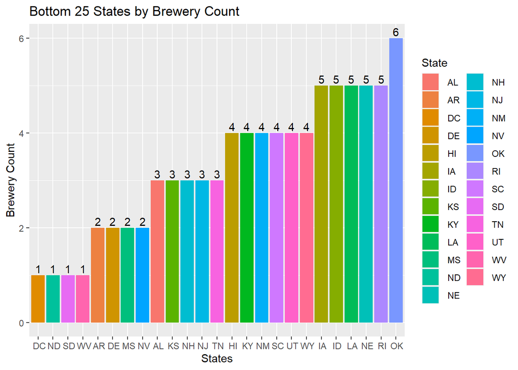

```r
# Bottom 25 States with Most Breweries


top_n(SummaryBrewery,25,-Brewery_Count) %>% ggplot(mapping = aes(x = reorder(State,Brewery_Count), y = Brewery_Count, fill = State)) + geom_bar(stat = 'identity') + ggtitle("Bottom 25 States by Brewery Count") + xlab("States") + ylab("Brewery Count") +geom_text(aes(label = format(Brewery_Count,big.mark =',')), position = position_dodge(width = .9), vjust = -.25)
```

### 2. Merge beer data with the breweries data. Print the first 6 observations and the last six observations to check the merged file.

```r
#This code will merge the Data with assigning each beer with the brewery and location

#Merge Data
#outer join (keep all observations from both dataframes)
names(Beers)[5] <- "Brew_ID"
names(Breweries)[2] <- "Brewery_Name"
bbdf <- merge(Beers,Breweries, by = "Brew_ID")

#Head
bbdf %>% head(6)
```

```
##   Brew_ID          Name Beer_ID   ABV IBU                               Style
## 1       1  Get Together    2692 0.045  50                        American IPA
## 2       1 Maggie's Leap    2691 0.049  26                  Milk / Sweet Stout
## 3       1    Wall's End    2690 0.048  19                   English Brown Ale
## 4       1       Pumpion    2689 0.060  38                         Pumpkin Ale
## 5       1    Stronghold    2688 0.060  25                     American Porter
## 6       1   Parapet ESB    2687 0.056  47 Extra Special / Strong Bitter (ESB)
##   Ounces       Brewery_Name        City State
## 1     16 NorthGate Brewing  Minneapolis    MN
## 2     16 NorthGate Brewing  Minneapolis    MN
## 3     16 NorthGate Brewing  Minneapolis    MN
## 4     16 NorthGate Brewing  Minneapolis    MN
## 5     16 NorthGate Brewing  Minneapolis    MN
## 6     16 NorthGate Brewing  Minneapolis    MN
```

```r
#tail
bbdf %>% tail(6)
```

```
##      Brew_ID                      Name Beer_ID   ABV IBU
## 2405     556             Pilsner Ukiah      98 0.055  NA
## 2406     557  Heinnieweisse Weissebier      52 0.049  NA
## 2407     557           Snapperhead IPA      51 0.068  NA
## 2408     557         Moo Thunder Stout      50 0.049  NA
## 2409     557         Porkslap Pale Ale      49 0.043  NA
## 2410     558 Urban Wilderness Pale Ale      30 0.049  NA
##                        Style Ounces                  Brewery_Name          City
## 2405         German Pilsener     12         Ukiah Brewing Company         Ukiah
## 2406              Hefeweizen     12       Butternuts Beer and Ale Garrattsville
## 2407            American IPA     12       Butternuts Beer and Ale Garrattsville
## 2408      Milk / Sweet Stout     12       Butternuts Beer and Ale Garrattsville
## 2409 American Pale Ale (APA)     12       Butternuts Beer and Ale Garrattsville
## 2410        English Pale Ale     12 Sleeping Lady Brewing Company     Anchorage
##      State
## 2405    CA
## 2406    NY
## 2407    NY
## 2408    NY
## 2409    NY
## 2410    AK
```

### 3. Address the missing values in each column.

```r
#Cleanse data
#We chose to omit the NA records as a method to clean the data
bbdf_clean = na.omit(bbdf)
```

### 4. Median of alcohol content and bitterness by each state.

```r
#This code will create a table of Medians for ABV and IBU for each state and graphically display a bar chart


# created a clean table with stats for ABV and IBU
bbdf_clean_stats = bbdf_clean %>% group_by(State) %>% summarise(Mean_ABV=mean(ABV), Max_ABV=max(ABV), Min_ABV=min(ABV), Median_ABV=median(ABV), Std_ABV=sd(ABV),Mean_IBU=mean(IBU), Max_IBU=max(IBU), Min_IBU=min(IBU), Median_IBU=median(IBU), Std_IBU=sd(IBU))

# Clean table with Medians for ABV and IBU
bbdf_clean_Medians = bbdf_clean_stats %>% select(State, Median_ABV, Median_IBU)
bbdf_clean_Medians
```

```
## # A tibble: 50 x 3
##    State Median_ABV Median_IBU
##    <chr>      <dbl>      <dbl>
##  1 " AK"     0.057        46
##  2 " AL"     0.06         43
##  3 " AR"     0.04         39
##  4 " AZ"     0.0575       20.5
##  5 " CA"     0.058        42
##  6 " CO"     0.065        40
##  7 " CT"     0.061        29
##  8 " DC"     0.059        47.5
##  9 " DE"     0.055        52
## 10 " FL"     0.062        55
## # ... with 40 more rows
```

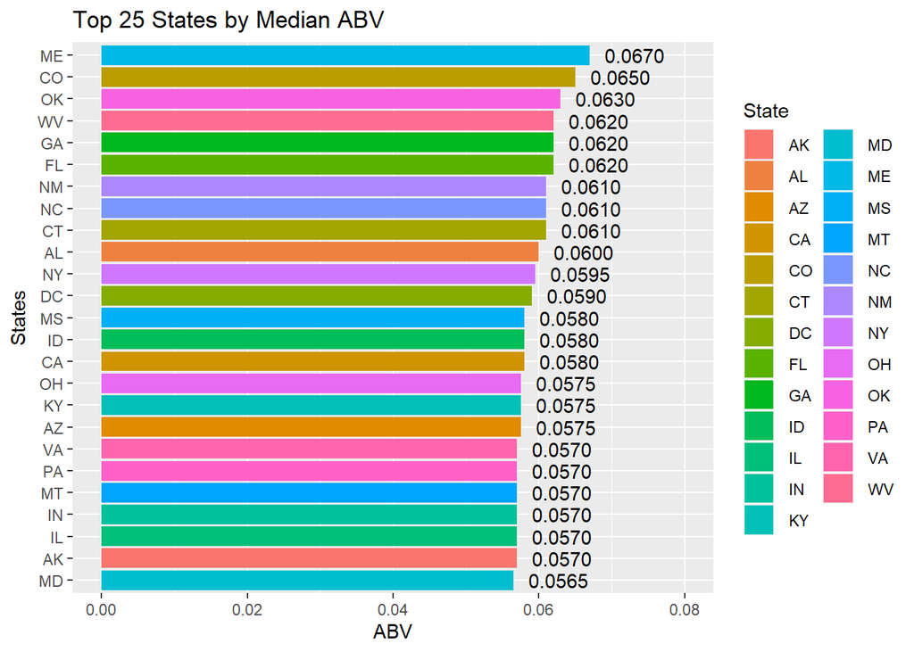

```r
# Top 25 States by Median ABV
top_n(bbdf_clean_Medians,25,Median_ABV) %>% ggplot(mapping = aes(x = reorder(State,Median_ABV), y = Median_ABV, fill = State)) + geom_bar(stat = 'identity') + ggtitle("Top 25 States by Median ABV") + xlab("States") + ylab("ABV") +ylim(0,.08) +geom_text(aes(label = format(Median_ABV,big.mark =',')), position = position_dodge(width = .6), hjust = -.25) + coord_flip()
```

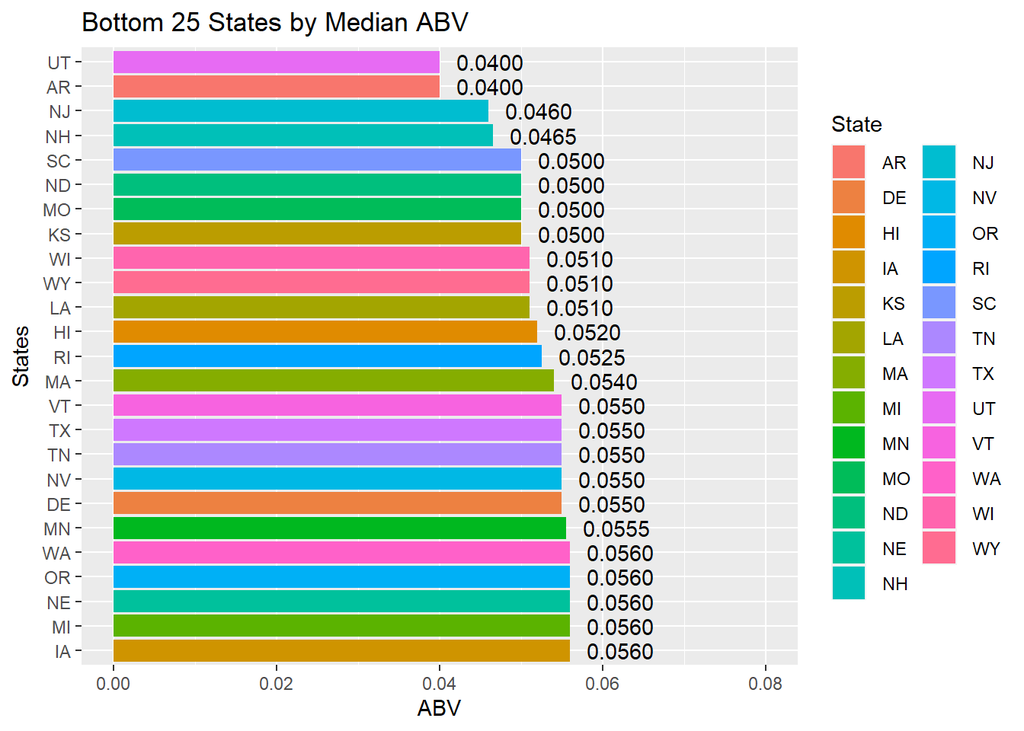

```r
# Bottom 25 States by Median ABV
top_n(bbdf_clean_Medians,25,-Median_ABV) %>% ggplot(mapping = aes(x = reorder(State,-Median_ABV), y = Median_ABV, fill = State)) + geom_bar(stat = 'identity') + ggtitle("Bottom 25 States by Median ABV") + xlab("States") + ylab("ABV") +ylim(0,.08) +geom_text(aes(label = format(Median_ABV,big.mark =',')), position = position_dodge(width = .6), hjust = -.25) + coord_flip()
```

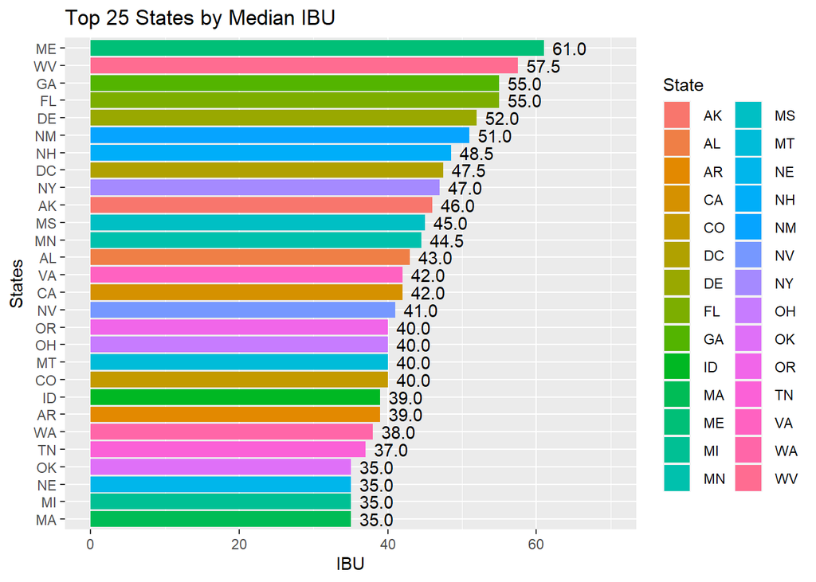

```r
# Top 25 States by Median IBU
top_n(bbdf_clean_Medians,25,Median_IBU) %>%  ggplot(mapping = aes(x = reorder(State,Median_IBU), y = Median_IBU, fill = State)) + geom_bar(stat = 'identity') + ggtitle("Top 25 States by Median IBU") + xlab("States") + ylab("IBU") +ylim(0,70) +geom_text(aes(label = format(Median_IBU,big.mark =',')), position = position_dodge(width = .6), hjust = -.25) + coord_flip()
```

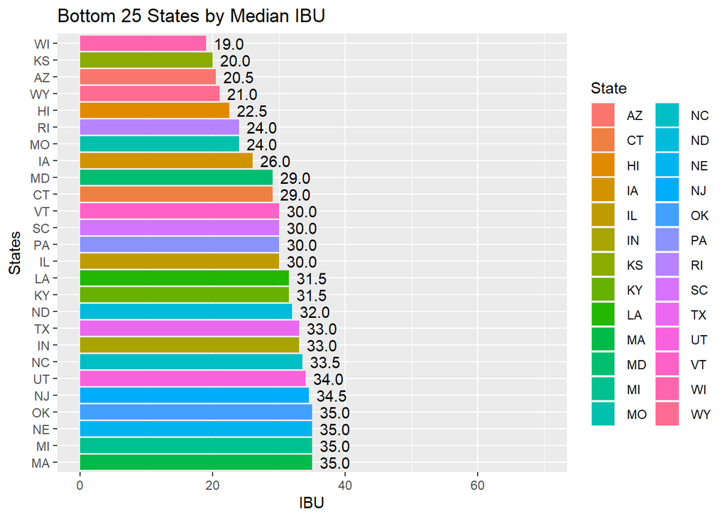

```r
# Bottom 25 States by Median IBU
top_n(bbdf_clean_Medians,25,-Median_IBU) %>% ggplot(mapping = aes(x = reorder(State,-Median_IBU), y = Median_IBU, fill = State)) + geom_bar(stat = 'identity') + ggtitle("Bottom 25 States by Median IBU") + xlab("States") + ylab("IBU") +ylim(0,70) +geom_text(aes(label = format(Median_IBU,big.mark =',')), position = position_dodge(width = .6), hjust = -.25) + coord_flip()
```

### 5. Which state has the maximum alcoholic (ABV) beer? Which state has the most bitter (IBU) beer?

```r
#This code will identify which State has the highest ABV and IBU beers.


# State with the max ABV
bbdf_clean %>% filter(ABV == max(ABV))
```

```
##   Brew_ID           Name Beer_ID   ABV IBU              Style Ounces
## 1       2 London Balling    2685 0.125  80 English Barleywine     16
##                Brewery_Name       City State
## 1 Against the Grain Brewery Louisville    KY
```

```r
#KY has the Max ABV of .125 based on London Balling from the Against the Grain Brewery

#State with the max IBU
bbdf_clean %>% filter(IBU == max(IBU))
```

```
##   Brew_ID                      Name Beer_ID   ABV IBU
## 1     375 Bitter Bitch Imperial IPA     980 0.082 138
##                            Style Ounces            Brewery_Name    City State
## 1 American Double / Imperial IPA     12 Astoria Brewing Company Astoria    OR
```

```r
#OR has the Max IBU of 138 based on the Bitter Bitch Imperial IPA from the Astoria Brewing Company
```

### 6.Comment on the summary statistics and distribution of the ABV variable.

```r
#This code will create a summary statistic of the ABV variable

# already have that in the bbdf_clean_stats

# created a clean table with stats for ABV
bbdf_clean_stats = bbdf_clean %>% group_by(State) %>% summarise(Mean_ABV=mean(ABV), Max_ABV=max(ABV), Min_ABV=min(ABV), Median_ABV=median(ABV), Std_ABV=sd(ABV))
```

### 7. Is there an apparent relationship between the bitterness of the beer and its alcoholic content? Draw a scatter plot. Make your best judgment of a relationship and EXPLAIN your answer

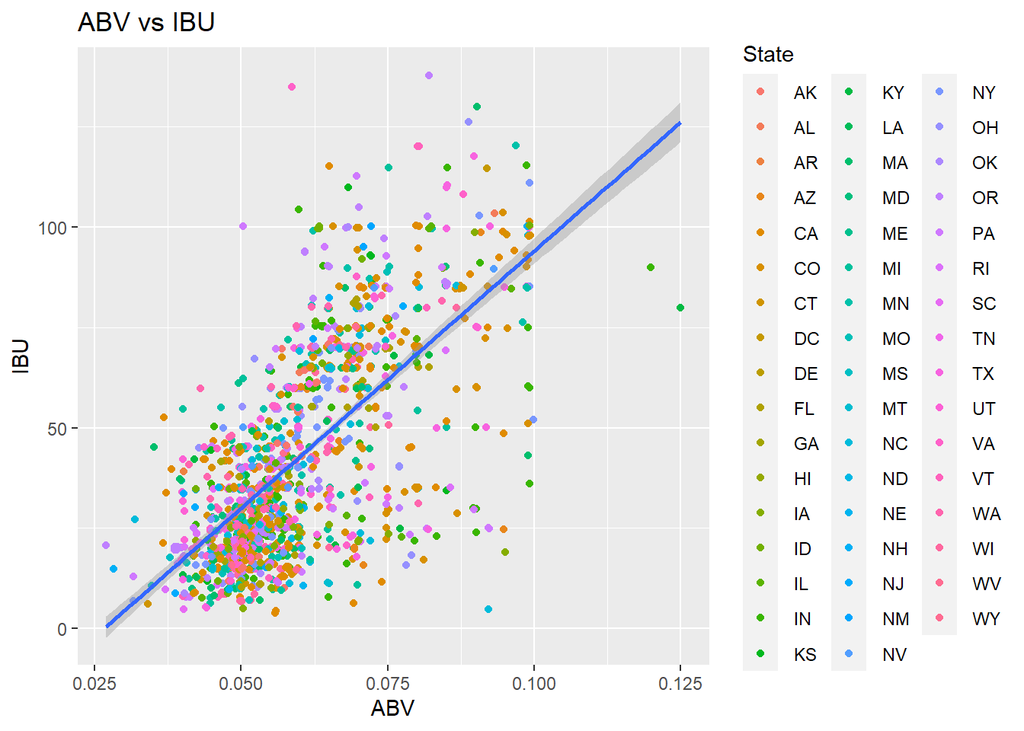

```r
# Scatter Plot to show relationship for the ABV and IBU

bbdf_clean %>% ggplot(mapping = aes(x = ABV, y = IBU)) + geom_point(mapping = aes(x = ABV, y = IBU, color = State), position = "jitter") +  geom_smooth(method='lm', formula= y~x) + ggtitle("ABV vs IBU") + xlab("ABV") + ylab("IBU")
```

```r
# there is a linear positive correlation between ABV and IBU based on the linear model of the data set.
```